# Homework 4

Katherine Leu

July 2, 2018

```r
library(nycflights13)
library(tidyverse)
```

## Section 5.6.7:

### 2. Come up with another approach that will give you the same output as `not_cancelled %>% count(dest)` and `not_cancelled %>% count(tailnum, wt = distance)` (without using `count()`).

First, I look at the output to be recreated:

```r
not_cancelled <- flights %>%
  filter(!is.na(dep_delay), !is.na(arr_delay))

not_cancelled %>% count(dest)
```

```
## # A tibble: 104 x 2
##    dest      n
##    <chr> <int>
##  1 ABQ     254
##  2 ACK     264
##  3 ALB     418
##  4 ANC       8
##  5 ATL   16837
##  6 AUS    2411
##  7 AVL     261
##  8 BDL     412
##  9 BGR     358
## 10 BHM     269
## # ... with 94 more rows
```

```r
not_cancelled %>% count(tailnum, wt = distance)
```

```
## # A tibble: 4,037 x 2
##    tailnum      n
##    <chr>    <dbl>
##  1 D942DN    3418
##  2 N0EGMQ  239143
##  3 N10156  109664
##  4 N102UW   25722
##  5 N103US   24619
##  6 N104UW   24616
##  7 N10575  139903
##  8 N105UW   23618
##  9 N107US   21677
## 10 N108UW   32070
## # ... with 4,027 more rows
```

Here is a way to get the same output as `not_cancelled %>% count(dest)` without using `count()`:

```r
not_cancelled %>% group_by(dest) %>%
  summarize(
    count=n()
)
```

```
## # A tibble: 104 x 2
##    dest  count
##    <chr> <int>
##  1 ABQ     254
##  2 ACK     264
##  3 ALB     418
##  4 ANC       8
##  5 ATL   16837
##  6 AUS    2411
##  7 AVL     261
##  8 BDL     412
##  9 BGR     358
## 10 BHM     269
## # ... with 94 more rows
```

Here is a way to get the same output as `not_cancelled %>% count(tailnum, wt = distance)` without using `count()`:

```r
not_cancelled %>% group_by(tailnum) %>%
  summarize(
    n = sum(distance)
)
```

```
## # A tibble: 4,037 x 2
##    tailnum      n
##    <chr>    <dbl>
##  1 D942DN    3418
##  2 N0EGMQ  239143
##  3 N10156  109664
##  4 N102UW   25722
##  5 N103US   24619
##  6 N104UW   24616
##  7 N10575  139903
##  8 N105UW   23618
##  9 N107US   21677
## 10 N108UW   32070
## # ... with 4,027 more rows
```

### 4. Look at the number of cancelled flights per day. Is there a pattern? Is the proportion of cancelled flights related to the average delay?

Below, we calculate the number of canceled flights per day, the proportion of canceled flights per day, and the average delay:

```r
canceledbyday <- flights %>% group_by(year, month, day) %>%
  summarize(
    canceled = sum(is.na(arr_delay) | is.na(dep_delay)),
    prop_canceled = mean(is.na(arr_delay) | is.na(dep_delay)),
    avg_delay = mean(dep_delay, na.rm=TRUE)
  )
canceledbyday
```

```
## # A tibble: 365 x 6
## # Groups:   year, month [?]
##     year month   day canceled prop_canceled avg_delay
##    <int> <int> <int>    <int>         <dbl>     <dbl>
##  1  2013     1     1       11       0.0131      11.5
##  2  2013     1     2       15       0.0159      13.9
##  3  2013     1     3       14       0.0153      11.0
##  4  2013     1     4        7       0.00765      8.95
##  5  2013     1     5        3       0.00417      5.73
##  6  2013     1     6        3       0.00361      7.15
##  7  2013     1     7        3       0.00322      5.42
##  8  2013     1     8        7       0.00779      2.55
##  9  2013     1     9        9       0.00998      2.28
## 10  2013     1    10        3       0.00322      2.84
## # ... with 355 more rows
```

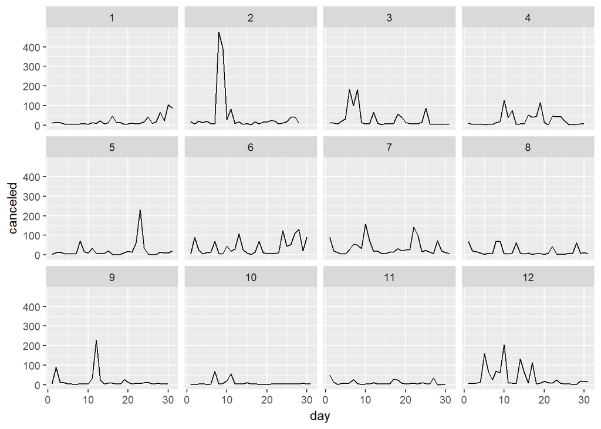

```r
ggplot(data=canceledbyday) +
    geom_line(mapping=aes(x=day, y=canceled)) +
    #geom_line(mapping=aes(x=day, y=avg_delay), color="red") +
    facet_wrap(~month)
```

Below is a scatterplot of the proportion of canceled flights against the average delay. It appears that there is a positive relationship between the proportion of canceled flights and the average delay.

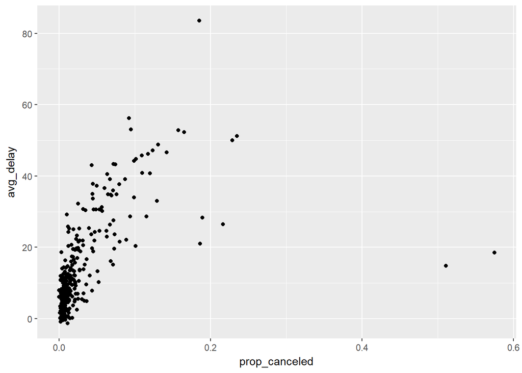

```r
ggplot(data=canceledbyday) +
    geom_point(mapping=aes(x=prop_canceled, y=avg_delay))
```

### 6. What does the `sort` argument to `count()` do. When might you use it?

The `sort` argument to `count()` sorts the output in descending order by count. You might use this if you want to look for patterns in your `group_by` variables by frequency, to see which group categories have the highest rate of frequency.

### 5. [EXTRA CREDIT] Which carrier has the worst delays? Challenge: can you disentangle the effects of bad airports vs. bad carriers? Why/why not? (Hint: think about `flights %>% group_by(carrier, dest) %>% summarise(n())`)

First, I look at average delays by carrier:

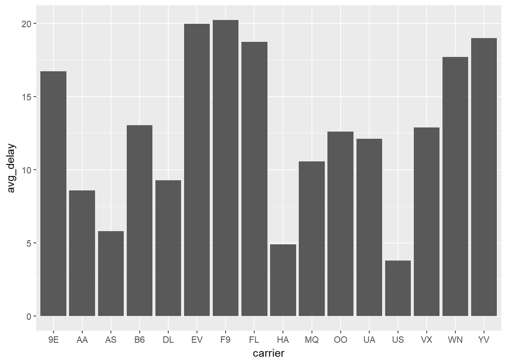

```r
flights %>% group_by(carrier) %>%
  summarize(
    avg_delay = mean(dep_delay, na.rm=TRUE)) %>%
  ggplot(mapping=aes(x=carrier, y=avg_delay)) +
    geom_col()
```

From the above graph, it looks like the carrier with the worst delays (here defined as the longest average delays) is F9, or Frontier Airlines, with EV, ExpressJet Airlines, a close second.

To try to disentangle “bad carriers” from “bad airports”, I look at the average delays by destination:

```r
badairport <- flights %>% group_by(dest) %>%
  summarize(
    avg_delay = mean(dep_delay, na.rm=TRUE)
  )
```

I further narrow these down to the airports with average delays at or above the 95th percentile.

```r
filter(badairport, avg_delay> quantile(avg_delay, 0.95, na.rm=TRUE))
```

```
## # A tibble: 6 x 2
##   dest  avg_delay
##   <chr>     <dbl>
## 1 BHM        29.7
## 2 CAE        35.6
## 3 JAC        26.5
## 4 OKC        30.6
## 5 TUL        34.9
## 6 TYS        28.5
```

It appears that the destination airports BHM, CAE, JAC, OKC, TUL, and TYS have the longest average delays, with CAE and TUL having particularly long delays.

Next I see if the carriers with the longest delays tend to service the airports with the longest delays:

```r
flights %>% group_by(carrier, dest) %>% summarize(n()) %>% filter(dest %in% c("BHM","CAE","JAC","OKC","TUL","TYS"))
```

```
## # A tibble: 9 x 3
## # Groups:   carrier [4]
##   carrier dest  `n()`
##   <chr>   <chr> <int>
## 1 9E      CAE       3
## 2 9E      TYS     308
## 3 DL      JAC       2
## 4 EV      BHM     297
## 5 EV      CAE     113
## 6 EV      OKC     346
## 7 EV      TUL     315
## 8 EV      TYS     323
## 9 UA      JAC      23
```

## Section 10.5:

### 1. How can you tell if an object is a tibble? (Hint: try printing `mtcars`, which is a regular data frame).

Printing the data frame `mtcars`:

```r
mtcars
```

```
##                      mpg cyl  disp  hp drat    wt  qsec vs am gear carb
## Mazda RX4           21.0   6 160.0 110 3.90 2.620 16.46  0  1    4    4
## Mazda RX4 Wag       21.0   6 160.0 110 3.90 2.875 17.02  0  1    4    4
## Datsun 710          22.8   4 108.0  93 3.85 2.320 18.61  1  1    4    1
## Hornet 4 Drive      21.4   6 258.0 110 3.08 3.215 19.44  1  0    3    1
## Hornet Sportabout   18.7   8 360.0 175 3.15 3.440 17.02  0  0    3    2
## Valiant             18.1   6 225.0 105 2.76 3.460 20.22  1  0    3    1
## Duster 360          14.3   8 360.0 245 3.21 3.570 15.84  0  0    3    4
## Merc 240D           24.4   4 146.7  62 3.69 3.190 20.00  1  0    4    2
## Merc 230            22.8   4 140.8  95 3.92 3.150 22.90  1  0    4    2
## Merc 280            19.2   6 167.6 123 3.92 3.440 18.30  1  0    4    4
## Merc 280C           17.8   6 167.6 123 3.92 3.440 18.90  1  0    4    4
## Merc 450SE          16.4   8 275.8 180 3.07 4.070 17.40  0  0    3    3
## Merc 450SL          17.3   8 275.8 180 3.07 3.730 17.60  0  0    3    3
## Merc 450SLC         15.2   8 275.8 180 3.07 3.780 18.00  0  0    3    3
## Cadillac Fleetwood  10.4   8 472.0 205 2.93 5.250 17.98  0  0    3    4
## Lincoln Continental 10.4   8 460.0 215 3.00 5.424 17.82  0  0    3    4
## Chrysler Imperial   14.7   8 440.0 230 3.23 5.345 17.42  0  0    3    4
## Fiat 128            32.4   4  78.7  66 4.08 2.200 19.47  1  1    4    1
## Honda Civic         30.4   4  75.7  52 4.93 1.615 18.52  1  1    4    2
## Toyota Corolla      33.9   4  71.1  65 4.22 1.835 19.90  1  1    4    1
## Toyota Corona       21.5   4 120.1  97 3.70 2.465 20.01  1  0    3    1
## Dodge Challenger    15.5   8 318.0 150 2.76 3.520 16.87  0  0    3    2
## AMC Javelin         15.2   8 304.0 150 3.15 3.435 17.30  0  0    3    2
## Camaro Z28          13.3   8 350.0 245 3.73 3.840 15.41  0  0    3    4
## Pontiac Firebird    19.2   8 400.0 175 3.08 3.845 17.05  0  0    3    2
## Fiat X1-9           27.3   4  79.0  66 4.08 1.935 18.90  1  1    4    1
## Porsche 914-2       26.0   4 120.3  91 4.43 2.140 16.70  0  1    5    2
## Lotus Europa        30.4   4  95.1 113 3.77 1.513 16.90  1  1    5    2
## Ford Pantera L      15.8   8 351.0 264 4.22 3.170 14.50  0  1    5    4
## Ferrari Dino        19.7   6 145.0 175 3.62 2.770 15.50  0  1    5    6
## Maserati Bora       15.0   8 301.0 335 3.54 3.570 14.60  0  1    5    8
## Volvo 142E          21.4   4 121.0 109 4.11 2.780 18.60  1  1    4    2
```

Printing the tibble `flights`:

```r
flights
```

```
## # A tibble: 336,776 x 19
##     year month   day dep_time sched_dep_time dep_delay arr_time
##    <int> <int> <int>    <int>          <int>     <dbl>    <int>
##  1  2013     1     1      517            515         2      830
##  2  2013     1     1      533            529         4      850
##  3  2013     1     1      542            540         2      923
##  4  2013     1     1      544            545        -1     1004
##  5  2013     1     1      554            600        -6      812
##  6  2013     1     1      554            558        -4      740
##  7  2013     1     1      555            600        -5      913
##  8  2013     1     1      557            600        -3      709
##  9  2013     1     1      557            600        -3      838
## 10  2013     1     1      558            600        -2      753
## # ... with 336,766 more rows, and 12 more variables: sched_arr_time <int>,
## #   arr_delay <dbl>, carrier <chr>, flight <int>, tailnum <chr>,
## #   origin <chr>, dest <chr>, air_time <dbl>, distance <dbl>, hour <dbl>,
## #   minute <dbl>, time_hour <dttm>
```

You can tell that an object is a tibble because when printed, R tells you that it’s a tibble. In addition, the output from printing a tibble doesn’t display all rows but rather just the first 10 rows and as many variables as will fit on the screen (with information about how many more rows and variables there are). In contrast, printing a data frame will display all rows and variables.

### 2. Compare and contrast the following operations on a data.frame and equivalent tibble. What is different? Why might the default data frame behaviours cause you frustration?

```r
#df <- data.frame(abc = 1, xyz = "a")
#df$x
#df[, "xyz"]
#df[, c("abc", "xyz")]
```

First, I create the equivalent tibble and contrast the first set of operations:

```r
df <- data.frame(abc = 1, xyz = "a")
tb <- tibble(abc = 1, xyz = "a")

df$x
```

```
## [1] a
## Levels: a
```

```r
tb$x
```

[output not shown]

As shown above, the first operation, `$x`, returns the value of `xyz` when applied to the data frame. When applied to the equivalent tibble, a `NULL` value is returned, because variables can’t be extracted from tibbles using partial names. This data frame behavior may cause frustration if there exist multiple variables in the same data frame that start with the same few letters–if you aren’t precise in specifying the variable name, you may end up calling the wrong variable.

```r
df[, "xyz"]
```

```
## [1] a
## Levels: a
```

```r
tb[, "xyz"]
```

```
## # A tibble: 1 x 1
##   xyz
##   <chr>
## 1 a
```

The second operation, `[, "xyz"]`, returns the value and levels of the variable when applied to the data frame. When applied to a tibble, it returns the value of the variable and provides information about the variable’s type. The default data frame behavior is to convert the character variable into a factor variable (which is why levels are displayed); this may be frustrating if you don’t want your character variable to be treated as a factor.

```r
df[, c("abc", "xyz")]
```

```
##   abc xyz
## 1   1   a
```

```r
tb[, c("abc", "xyz")]
```

```
## # A tibble: 1 x 2
##     abc xyz
##   <dbl> <chr>
## 1     1 a
```

The third operation, `[, c("abc", "xyz")]`, returns the variable names and values when applied to the data frame, and returns the variable names, values, and types when applied to the tibble. The default data frame behavior may cause frustration because you can’t necessarily tell from the output what the types of the variables are.

### 3. If you have the name of a variable stored in an object, e.g. `var <- "mpg"`, how can you extract the reference variable from a tibble?

If you have the name of a variable stored in an object, you could extract that variable from a tibble using the name of the object and `[[`:

```r
var <- "mpg"
as_tibble(mtcars)[[var]]
```

```
##  [1] 21.0 21.0 22.8 21.4 18.7 18.1 14.3 24.4 22.8 19.2 17.8 16.4 17.3 15.2
## [15] 10.4 10.4 14.7 32.4 30.4 33.9 21.5 15.5 15.2 13.3 19.2 27.3 26.0 30.4
## [29] 15.8 19.7 15.0 21.4
```

(You cannot use `$`, which will throw an error because the tibble has no column named `var`.)

### 6. What option controls how many additional column names are printed at the footer of a tibble?

Using `print`, the `n_extra` option controls the number of additional column names printed at the footer of a tibble. Below, first the default output for printing `flights` is shown. In the next command, `n_extra` is used to print column information for only 2 additional variables.

```r
flights
```

```
## # A tibble: 336,776 x 19
##     year month   day dep_time sched_dep_time dep_delay arr_time
##    <int> <int> <int>    <int>          <int>     <dbl>    <int>
##  1  2013     1     1      517            515         2      830
##  2  2013     1     1      533            529         4      850
##  3  2013     1     1      542            540         2      923
##  4  2013     1     1      544            545        -1     1004
##  5  2013     1     1      554            600        -6      812
##  6  2013     1     1      554            558        -4      740
##  7  2013     1     1      555            600        -5      913
##  8  2013     1     1      557            600        -3      709
##  9  2013     1     1      557            600        -3      838
## 10  2013     1     1      558            600        -2      753
## # ... with 336,766 more rows, and 12 more variables: sched_arr_time <int>,
## #   arr_delay <dbl>, carrier <chr>, flight <int>, tailnum <chr>,
## #   origin <chr>, dest <chr>, air_time <dbl>, distance <dbl>, hour <dbl>,
## #   minute <dbl>, time_hour <dttm>
```

```r
print(flights, n_extra = 2)
```

```
## # A tibble: 336,776 x 19
##     year month   day dep_time sched_dep_time dep_delay arr_time
##    <int> <int> <int>    <int>          <int>     <dbl>    <int>
##  1  2013     1     1      517            515         2      830
##  2  2013     1     1      533            529         4      850
##  3  2013     1     1      542            540         2      923
##  4  2013     1     1      544            545        -1     1004
##  5  2013     1     1      554            600        -6      812
##  6  2013     1     1      554            558        -4      740
##  7  2013     1     1      555            600        -5      913
##  8  2013     1     1      557            600        -3      709
##  9  2013     1     1      557            600        -3      838
## 10  2013     1     1      558            600        -2      753
## # ... with 336,766 more rows, and 12 more variables: sched_arr_time <int>,
## #   arr_delay <dbl>, ...
```

## Section 12.3.3:

### 2. Why does this code fail?

```r
#table4a %>%
#  gather(1999, 2000, key = "year", value = "cases")
```

```
#> Error in inds_combine(.vars, ind_list): Position must be between 0 and n
```

This code fails because the year variables, `1999` and `2000`, need to be referred to with backticks around their names, since R doesn’t recognize numbers as variable names otherwise. When this is fixed, the code works:

```r
table4a %>%
  gather(`1999`, `2000`, key = "year", value = "cases")
```

```
## # A tibble: 6 x 3
##   country     year   cases
##   <chr>       <chr>  <int>
## 1 Afghanistan 1999     745
## 2 Brazil      1999   37737
## 3 China       1999  212258
## 4 Afghanistan 2000    2666
## 5 Brazil      2000   80488
## 6 China       2000  213766
```

### 3. Why does spreading this tibble fail? How could you add a new column to fix the problem?

```r
people <- tribble(
  ~name,             ~key,    ~value,
  #-----------------|--------|------
  "Phillip Woods",   "age",       45,
  "Phillip Woods",   "height",   186,
  "Phillip Woods",   "age",       50,
  "Jessica Cordero", "age",       37,
  "Jessica Cordero", "height",   156
)
```

```r
# people %>% spread(key= key, value=value)
# Error: Duplicate identifiers for rows (1, 3)
```

Spreading this tibble fails because there are duplicate values in the first column, `name`. This might have happened because the dataset includes observations collected on the same individuals at multiple time points, say multiple waves of the same survey. Using this idea, you could fix the problem by adding a new column, `wave`, indicating the wave of the survey in which the measurement was taken.

```r
people2 <- tribble(
  ~name,             ~key,    ~value, ~wave,
  #-----------------|--------|-------|-----
  "Phillip Woods",   "age",       45,     1,
  "Phillip Woods",   "height",   186,     1,
  "Phillip Woods",   "age",       50,     2,
  "Jessica Cordero", "age",       37,     1,
  "Jessica Cordero", "height",   156,     1
)
```

```r
people2 %>% spread(key= key, value=value)
```

```
## # A tibble: 3 x 4
##   name             wave   age height
##   <chr>           <dbl> <dbl>  <dbl>
## 1 Jessica Cordero     1    37    156
## 2 Phillip Woods       1    45    186
## 3 Phillip Woods       2    50     NA
```

### 4. Tidy the simple tibble below. Do you need to spread or gather it? What are the variables?

```r
preg <- tribble(
  ~pregnant, ~male, ~female,
  "yes",     NA,    10,
  "no",      20,    12
)
```

You need to gather this tibble, because “male” and “female” are values of sex, not variables. The variables are “pregnant” and “sex”.

```r
preg %>% gather(male, female, key="sex", value= "cases")
```

```
## # A tibble: 4 x 3
##   pregnant sex    cases
##   <chr>    <chr>  <dbl>
## 1 yes      male      NA
## 2 no       male      20
## 3 yes      female    10
## 4 no       female    12
```

## Section 12.4.3:

### 1. What do the `extra` and `fill` arguments do in `separate()`? Experiment with the various options for the following two toy datasets.

```r
#tibble(x = c("a,b,c", "d,e,f,g", "h,i,j")) %>%
#  separate(x, c("one", "two", "three"))

#tibble(x = c("a,b,c", "d,e", "f,g,i")) %>%
#  separate(x, c("one", "two", "three"))
```

The `extra` argument specifies how to treat character vectors if there are too many values for the number of columns specified. `extra` can take any of 3 options: “warn”, “drop”, and “merge”. “Warn” provides a warning that there are too many values and drops the extras; “drop” drops the extras without a warning, and “merge” adds the extra value to the last column. Each of the options for `extra` is illustrated below:

```r
tibble(x = c("a,b,c", "d,e,f,g", "h,i,j")) %>%
  separate(x, c("one", "two", "three"), extra="warn")
```

```
## Warning: Expected 3 pieces. Additional pieces discarded in 1 rows [2].
```

```
## # A tibble: 3 x 3
##   one   two   three
##   <chr> <chr> <chr>
## 1 a     b     c
## 2 d     e     f
## 3 h     i     j
```

```r
tibble(x = c("a,b,c", "d,e,f,g", "h,i,j")) %>%
  separate(x, c("one", "two", "three"), extra="drop")
```

```
## # A tibble: 3 x 3
##   one   two   three
##   <chr> <chr> <chr>
## 1 a     b     c
## 2 d     e     f
## 3 h     i     j
```

```r
tibble(x = c("a,b,c", "d,e,f,g", "h,i,j")) %>%
  separate(x, c("one", "two", "three"), extra="merge")
```

```
## # A tibble: 3 x 3
##   one   two   three
##   <chr> <chr> <chr>
## 1 a     b     c
## 2 d     e     f,g
## 3 h     i     j
```

```r
tibble(x = c("a,b,c", "d,e", "f,g,i")) %>%
  separate(x, c("one", "two", "three"), fill="warn")
```

```
## Warning: Expected 3 pieces. Missing pieces filled with `NA` in 1 rows [2].
```

```
## # A tibble: 3 x 3
##   one   two   three
##   <chr> <chr> <chr>
## 1 a     b     c
## 2 d     e     <NA>
## 3 f     g     i
```

```r
tibble(x = c("a,b,c", "d,e", "f,g,i")) %>%
  separate(x, c("one", "two", "three"), fill="right")
```

```
## # A tibble: 3 x 3
##   one   two   three
##   <chr> <chr> <chr>
## 1 a     b     c
## 2 d     e     <NA>
## 3 f     g     i
```

```r
tibble(x = c("a,b,c", "d,e", "f,g,i")) %>%
  separate(x, c("one", "two", "three"), fill="left")
```

```
## # A tibble: 3 x 3
##   one   two   three
##   <chr> <chr> <chr>
## 1 a     b     c
## 2 <NA>  d     e
## 3 f     g     i
```

### 2. Both `unite()` and `separate()` have a `remove` argument. What does it do? Why would you set it to `FALSE`?

The `remove` argument in `unite()` and `separate()` specifies whether to include in your output tibble the original input column(s) that you used `unite()` or `separate()` to manipulate. You would set it to `FALSE` if you want to retain those original columns in the output tibble:

```r
tibble(x = c("a,b,c", "d,e,f", "g,h,i")) %>%
  separate(x, c("one", "two", "three"), remove=FALSE)
```

```
## # A tibble: 3 x 4
##   x     one   two   three
##   <chr> <chr> <chr> <chr>
## 1 a,b,c a     b     c
## 2 d,e,f d     e     f
## 3 g,h,i g     h     i
```

## Answer these questions:

### Follow these steps:

### - Download the baby_names.txt file from Canvas which is in the Homework 4 assignment section.

### - Load this file into R correctly and take a glimpse of the output.

### - Export this file as a csv file and call it ‘baby_names.csv’.

### - Reload the baby_names.csv file and take another glimpse.

### - Show all of your code and the output. There should be two data import lines of code, one data export line of code, and two glimpses of the data.

1. Loading the TXT file into R:

```r
baby_txt <- read_delim(file = 'C:/Users/Katie/Documents/R/compscix-415-2-assignments/baby_names.txt', delim = "|")
```

2. Taking a glimpse of the TXT file:

```r
glimpse(baby_txt)
```

```
## Observations: 30,000
## Variables: 5
## $ year <int> 1880, 1880, 1880, 1880, 1880, 1880, 1880, 1880, 1880, 188...
## $ sex  <chr> "F", "F", "F", "F", "F", "F", "F", "F", "F", "F", "F", "F...
## $ name <chr> "Mary", "Anna", "Emma", "Elizabeth", "Minnie", "Margaret"...
## $ n    <int> 7065, 2604, 2003, 1939, 1746, 1578, 1472, 1414, 1320, 128...
## $ prop <dbl> 0.072384329, 0.026679234, 0.020521700, 0.019865989, 0.017...
```

3. Exporting the file as a CSV file:

```r
baby_csv <- write_csv(baby_txt, path = 'C:/Users/Katie/Documents/R/compscix-415-2-assignments/baby_names.csv')
```

4. Reloading the new CSV file:

```r
baby_newcsv = read_csv(file = 'C:/Users/Katie/Documents/R/compscix-415-2-assignments/baby_names.csv')
```

5. Taking a glimpse of the new CSV file:

```r
glimpse(baby_newcsv)
```

```
## Observations: 30,000
## Variables: 5
## $ year <int> 1880, 1880, 1880, 1880, 1880, 1880, 1880, 1880, 1880, 188...
## $ sex  <chr> "F", "F", "F", "F", "F", "F", "F", "F", "F", "F", "F", "F...
## $ name <chr> "Mary", "Anna", "Emma", "Elizabeth", "Minnie", "Margaret"...
## $ n    <int> 7065, 2604, 2003, 1939, 1746, 1578, 1472, 1414, 1320, 128...
## $ prop <dbl> 0.072384329, 0.026679234, 0.020521700, 0.019865989, 0.017...
```